# Risk Factor Analysis

## Outcome Variable

**Outcome Variable:** stunted

## Predictor Variables

**Intervention Variable:** safeh20

**Adjustment Set:**

- arm
- sex
- W_mage
- meducyrs
- feducyrs
- hhwealth_quart
- hfoodsec
- W_mhtcm
- W_nrooms
- W_nchldlt5
- W_parity
- impfloor
- impsan
- delta_W_mage
- delta_meducyrs
- delta_feducyrs
- delta_hhwealth_quart
- delta_hfoodsec
- delta_W_mhtcm
- delta_W_nrooms
- delta_W_nchldlt5
- delta_W_parity
- delta_impfloor
- delta_impsan

## Stratifying Variables

The analysis was stratified on these variable(s):

- agecat
- studyid
- country

## Data Summary

| agecat | studyid | country | safeh20 | stunted | n_cell | n |
| --- | --- | --- | --- | --- | --- | --- |
| Birth | ki0047075b-MAL-ED | BANGLADESH | 0 | 0 | 196 | 234 |
| Birth | ki0047075b-MAL-ED | BANGLADESH | 0 | 1 | 38 | 234 |
| Birth | ki0047075b-MAL-ED | BANGLADESH | 1 | 0 | 0 | 234 |
| Birth | ki0047075b-MAL-ED | BANGLADESH | 1 | 1 | 0 | 234 |
| Birth | ki0047075b-MAL-ED | BRAZIL | 0 | 0 | 113 | 124 |
| Birth | ki0047075b-MAL-ED | BRAZIL | 0 | 1 | 11 | 124 |
| Birth | ki0047075b-MAL-ED | BRAZIL | 1 | 0 | 0 | 124 |
| Birth | ki0047075b-MAL-ED | BRAZIL | 1 | 1 | 0 | 124 |
| Birth | ki0047075b-MAL-ED | INDIA | 0 | 0 | 161 | 191 |
| Birth | ki0047075b-MAL-ED | INDIA | 0 | 1 | 30 | 191 |
| Birth | ki0047075b-MAL-ED | INDIA | 1 | 0 | 0 | 191 |
| Birth | ki0047075b-MAL-ED | INDIA | 1 | 1 | 0 | 191 |
| Birth | ki0047075b-MAL-ED | NEPAL | 0 | 0 | 150 | 168 |
| Birth | ki0047075b-MAL-ED | NEPAL | 0 | 1 | 17 | 168 |
| Birth | ki0047075b-MAL-ED | NEPAL | 1 | 0 | 1 | 168 |
| Birth | ki0047075b-MAL-ED | NEPAL | 1 | 1 | 0 | 168 |
| Birth | ki0047075b-MAL-ED | PERU | 0 | 0 | 211 | 247 |
| Birth | ki0047075b-MAL-ED | PERU | 0 | 1 | 27 | 247 |
| Birth | ki0047075b-MAL-ED | PERU | 1 | 0 | 8 | 247 |
| Birth | ki0047075b-MAL-ED | PERU | 1 | 1 | 1 | 247 |
| Birth | ki0047075b-MAL-ED | SOUTH AFRICA | 0 | 0 | 164 | 216 |
| Birth | ki0047075b-MAL-ED | SOUTH AFRICA | 0 | 1 | 19 | 216 |
| Birth | ki0047075b-MAL-ED | SOUTH AFRICA | 1 | 0 | 31 | 216 |
| Birth | ki0047075b-MAL-ED | SOUTH AFRICA | 1 | 1 | 2 | 216 |
| Birth | ki0047075b-MAL-ED | TANZANIA, UNITED REPUBLIC OF | 0 | 0 | 30 | 118 |
| Birth | ki0047075b-MAL-ED | TANZANIA, UNITED REPUBLIC OF | 0 | 1 | 9 | 118 |
| Birth | ki0047075b-MAL-ED | TANZANIA, UNITED REPUBLIC OF | 1 | 0 | 72 | 118 |
| Birth | ki0047075b-MAL-ED | TANZANIA, UNITED REPUBLIC OF | 1 | 1 | 7 | 118 |
| Birth | ki1017093-NIH-Birth | BANGLADESH | 0 | 0 | 0 | 28 |
| Birth | ki1017093-NIH-Birth | BANGLADESH | 0 | 1 | 0 | 28 |

[output cut: 130 more lines]

The following strata were considered:

- agecat: 24 months, studyid: ki0047075b-MAL-ED, country: BANGLADESH
- agecat: 24 months, studyid: ki0047075b-MAL-ED, country: BRAZIL
- agecat: 24 months, studyid: ki0047075b-MAL-ED, country: INDIA
- agecat: 24 months, studyid: ki0047075b-MAL-ED, country: NEPAL
- agecat: 24 months, studyid: ki0047075b-MAL-ED, country: PERU
- agecat: 24 months, studyid: ki0047075b-MAL-ED, country: SOUTH AFRICA
- agecat: 24 months, studyid: ki0047075b-MAL-ED, country: TANZANIA, UNITED REPUBLIC OF
- agecat: 24 months, studyid: ki1017093-NIH-Birth, country: BANGLADESH
- agecat: 24 months, studyid: ki1017093b-PROVIDE, country: BANGLADESH
- agecat: 24 months, studyid: ki1017093c-NIH-Crypto, country: BANGLADESH
- agecat: 24 months, studyid: ki1114097-CONTENT, country: PERU
- agecat: 24 months, studyid: ki1148112-LCNI-5, country: MALAWI
- agecat: 24 months, studyid: kiGH5241-JiVitA-3, country: BANGLADESH
- agecat: 24 months, studyid: kiGH5241-JiVitA-4, country: BANGLADESH
- agecat: 6 months, studyid: ki0047075b-MAL-ED, country: BANGLADESH
- agecat: 6 months, studyid: ki0047075b-MAL-ED, country: BRAZIL
- agecat: 6 months, studyid: ki0047075b-MAL-ED, country: INDIA
- agecat: 6 months, studyid: ki0047075b-MAL-ED, country: NEPAL
- agecat: 6 months, studyid: ki0047075b-MAL-ED, country: PERU
- agecat: 6 months, studyid: ki0047075b-MAL-ED, country: SOUTH AFRICA
- agecat: 6 months, studyid: ki0047075b-MAL-ED, country: TANZANIA, UNITED REPUBLIC OF
- agecat: 6 months, studyid: ki1000304b-SAS-FoodSuppl, country: INDIA
- agecat: 6 months, studyid: ki1017093-NIH-Birth, country: BANGLADESH
- agecat: 6 months, studyid: ki1017093b-PROVIDE, country: BANGLADESH
- agecat: 6 months, studyid: ki1017093c-NIH-Crypto, country: BANGLADESH
- agecat: 6 months, studyid: ki1114097-CONTENT, country: PERU
- agecat: 6 months, studyid: ki1148112-LCNI-5, country: MALAWI
- agecat: 6 months, studyid: kiGH5241-JiVitA-3, country: BANGLADESH
- agecat: 6 months, studyid: kiGH5241-JiVitA-4, country: BANGLADESH
- agecat: Birth, studyid: ki0047075b-MAL-ED, country: BANGLADESH
- agecat: Birth, studyid: ki0047075b-MAL-ED, country: BRAZIL
- agecat: Birth, studyid: ki0047075b-MAL-ED, country: INDIA
- agecat: Birth, studyid: ki0047075b-MAL-ED, country: NEPAL
- agecat: Birth, studyid: ki0047075b-MAL-ED, country: PERU
- agecat: Birth, studyid: ki0047075b-MAL-ED, country: SOUTH AFRICA
- agecat: Birth, studyid: ki0047075b-MAL-ED, country: TANZANIA, UNITED REPUBLIC OF
- agecat: Birth, studyid: ki1017093-NIH-Birth, country: BANGLADESH
- agecat: Birth, studyid: ki1017093c-NIH-Crypto, country: BANGLADESH
- agecat: Birth, studyid: kiGH5241-JiVitA-3, country: BANGLADESH
- agecat: Birth, studyid: kiGH5241-JiVitA-4, country: BANGLADESH

### Dropped Strata

Some strata were dropped due to rare outcomes:

- agecat: Birth, studyid: ki0047075b-MAL-ED, country: BANGLADESH
- agecat: Birth, studyid: ki0047075b-MAL-ED, country: BRAZIL
- agecat: Birth, studyid: ki0047075b-MAL-ED, country: INDIA
- agecat: Birth, studyid: ki0047075b-MAL-ED, country: NEPAL
- agecat: Birth, studyid: ki0047075b-MAL-ED, country: PERU
- agecat: Birth, studyid: ki0047075b-MAL-ED, country: SOUTH AFRICA
- agecat: Birth, studyid: ki1017093-NIH-Birth, country: BANGLADESH
- agecat: Birth, studyid: ki1017093c-NIH-Crypto, country: BANGLADESH
- agecat: Birth, studyid: kiGH5241-JiVitA-4, country: BANGLADESH
- agecat: 6 months, studyid: ki0047075b-MAL-ED, country: BANGLADESH
- agecat: 6 months, studyid: ki0047075b-MAL-ED, country: BRAZIL
- agecat: 6 months, studyid: ki0047075b-MAL-ED, country: INDIA
- agecat: 6 months, studyid: ki0047075b-MAL-ED, country: NEPAL
- agecat: 6 months, studyid: ki0047075b-MAL-ED, country: PERU
- agecat: 6 months, studyid: ki1000304b-SAS-FoodSuppl, country: INDIA
- agecat: 6 months, studyid: ki1017093-NIH-Birth, country: BANGLADESH
- agecat: 6 months, studyid: ki1017093b-PROVIDE, country: BANGLADESH
- agecat: 6 months, studyid: ki1017093c-NIH-Crypto, country: BANGLADESH
- agecat: 6 months, studyid: ki1114097-CONTENT, country: PERU
- agecat: 6 months, studyid: kiGH5241-JiVitA-4, country: BANGLADESH
- agecat: 24 months, studyid: ki0047075b-MAL-ED, country: BANGLADESH
- agecat: 24 months, studyid: ki0047075b-MAL-ED, country: BRAZIL
- agecat: 24 months, studyid: ki0047075b-MAL-ED, country: INDIA
- agecat: 24 months, studyid: ki0047075b-MAL-ED, country: NEPAL
- agecat: 24 months, studyid: ki0047075b-MAL-ED, country: PERU
- agecat: 24 months, studyid: ki1017093-NIH-Birth, country: BANGLADESH
- agecat: 24 months, studyid: ki1017093b-PROVIDE, country: BANGLADESH
- agecat: 24 months, studyid: ki1017093c-NIH-Crypto, country: BANGLADESH
- agecat: 24 months, studyid: ki1114097-CONTENT, country: PERU
- agecat: 24 months, studyid: kiGH5241-JiVitA-4, country: BANGLADESH

## Methods Detail

We’re interested in the causal parameters $E[Y_a]$ for all values of $a \in \mathcal{A}$. These parameters represent the mean outcome if, possibly contrary to fact, we intervened to set all units to have $A=a$. Under the randomization and positivity assumptions, these are identified by the statistical parameters $\psi_a=E_W[E_{Y|A,W}(Y|A=a,W)]$. In addition, we’re interested in the mean of $Y$, $E[Y]$ under no intervention (the observed mean). We will estimate these parameters by using SuperLearner to fit the relevant likelihood factors – $E_{Y|A,W}(Y|A=a,W)$ and $p(A=a|W)$, and then updating our likelihood fit using a joint TMLE.

For unadjusted analyses ($W=\{\}$), initial likelihoods were estimated using Lrnr_glm to estimate the simple $E(Y|A)$ and Lrnr_mean to estimate $p(A)$. For adjusted analyses, a small library containing Lrnr_glmnet, Lrnr_xgboost, and Lrnr_mean was used.

Having estimated these parameters, we will then use the delta method to estimate relative risks and attributable risks relative to a prespecified baseline level of $A$.

# Results Detail

## Results Plots

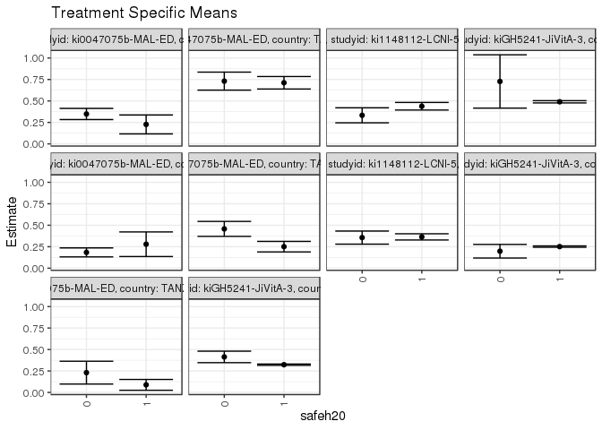

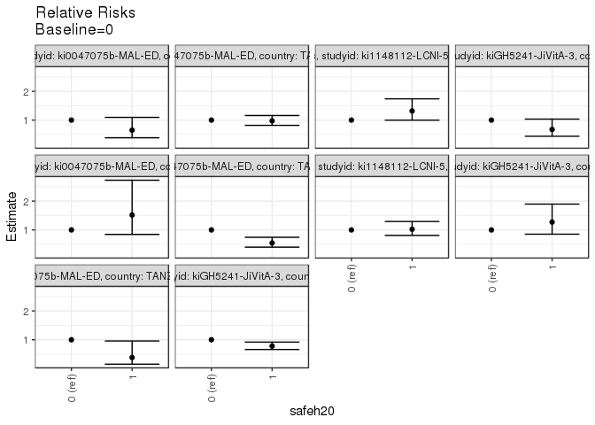

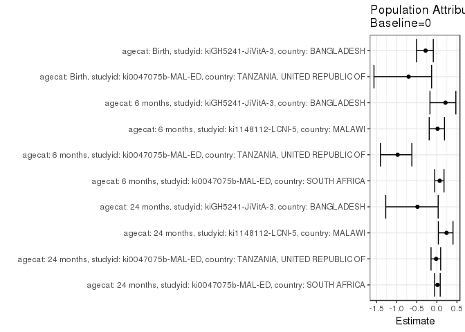

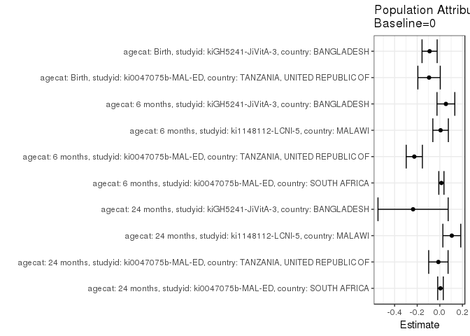

## Results Table

### Parameter: TSM

| agecat | studyid | country | intervention_level | baseline_level | estimate | ci_lower | ci_upper |
| --- | --- | --- | --- | --- | --- | --- | --- |
| Birth | ki0047075b-MAL-ED | TANZANIA, UNITED REPUBLIC OF | 0 | NA | 0.2307692 | 0.0979744 | 0.3635641 |
| Birth | ki0047075b-MAL-ED | TANZANIA, UNITED REPUBLIC OF | 1 | NA | 0.0886076 | 0.0256757 | 0.1515395 |
| Birth | kiGH5241-JiVitA-3 | BANGLADESH | 0 | NA | 0.4137529 | 0.3469294 | 0.4805763 |
| Birth | kiGH5241-JiVitA-3 | BANGLADESH | 1 | NA | 0.3230562 | 0.3153849 | 0.3307276 |
| 6 months | ki0047075b-MAL-ED | SOUTH AFRICA | 0 | NA | 0.1837190 | 0.1314437 | 0.2359942 |
| 6 months | ki0047075b-MAL-ED | SOUTH AFRICA | 1 | NA | 0.2788124 | 0.1356573 | 0.4219675 |
| 6 months | ki0047075b-MAL-ED | TANZANIA, UNITED REPUBLIC OF | 0 | NA | 0.4575010 | 0.3704296 | 0.5445724 |
| 6 months | ki0047075b-MAL-ED | TANZANIA, UNITED REPUBLIC OF | 1 | NA | 0.2504918 | 0.1892605 | 0.3117230 |
| 6 months | ki1148112-LCNI-5 | MALAWI | 0 | NA | 0.3559576 | 0.2797531 | 0.4321621 |
| 6 months | ki1148112-LCNI-5 | MALAWI | 1 | NA | 0.3642089 | 0.3280855 | 0.4003323 |
| 6 months | kiGH5241-JiVitA-3 | BANGLADESH | 0 | NA | 0.1975618 | 0.1183401 | 0.2767835 |
| 6 months | kiGH5241-JiVitA-3 | BANGLADESH | 1 | NA | 0.2512423 | 0.2431274 | 0.2593572 |
| 24 months | ki0047075b-MAL-ED | SOUTH AFRICA | 0 | NA | 0.3484571 | 0.2835302 | 0.4133840 |
| 24 months | ki0047075b-MAL-ED | SOUTH AFRICA | 1 | NA | 0.2266729 | 0.1164716 | 0.3368742 |
| 24 months | ki0047075b-MAL-ED | TANZANIA, UNITED REPUBLIC OF | 0 | NA | 0.7310701 | 0.6262474 | 0.8358927 |
| 24 months | ki0047075b-MAL-ED | TANZANIA, UNITED REPUBLIC OF | 1 | NA | 0.7120165 | 0.6393448 | 0.7846882 |
| 24 months | ki1148112-LCNI-5 | MALAWI | 0 | NA | 0.3329558 | 0.2453816 | 0.4205299 |
| 24 months | ki1148112-LCNI-5 | MALAWI | 1 | NA | 0.4384415 | 0.3943672 | 0.4825157 |
| 24 months | kiGH5241-JiVitA-3 | BANGLADESH | 0 | NA | 0.7272721 | 0.4167795 | 1.0377646 |
| 24 months | kiGH5241-JiVitA-3 | BANGLADESH | 1 | NA | 0.4904573 | 0.4773254 | 0.5035893 |

### Parameter: E(Y)

| agecat | studyid | country | intervention_level | baseline_level | estimate | ci_lower | ci_upper |
| --- | --- | --- | --- | --- | --- | --- | --- |
| Birth | ki0047075b-MAL-ED | TANZANIA, UNITED REPUBLIC OF | NA | NA | 0.1355932 | 0.0735587 | 0.1976277 |
| Birth | kiGH5241-JiVitA-3 | BANGLADESH | NA | NA | 0.3232787 | 0.3156210 | 0.3309364 |
| 6 months | ki0047075b-MAL-ED | SOUTH AFRICA | NA | NA | 0.1975806 | 0.1479246 | 0.2472367 |
| 6 months | ki0047075b-MAL-ED | TANZANIA, UNITED REPUBLIC OF | NA | NA | 0.2317073 | 0.1788752 | 0.2845395 |
| 6 months | ki1148112-LCNI-5 | MALAWI | NA | NA | 0.3627451 | 0.3297365 | 0.3957537 |
| 6 months | kiGH5241-JiVitA-3 | BANGLADESH | NA | NA | 0.2514228 | 0.2432969 | 0.2595487 |
| 24 months | ki0047075b-MAL-ED | SOUTH AFRICA | NA | NA | 0.3544304 | 0.2934024 | 0.4154584 |
| 24 months | ki0047075b-MAL-ED | TANZANIA, UNITED REPUBLIC OF | NA | NA | 0.7183099 | 0.6577588 | 0.7788609 |
| 24 months | ki1148112-LCNI-5 | MALAWI | NA | NA | 0.4390244 | 0.3983906 | 0.4796582 |
| 24 months | kiGH5241-JiVitA-3 | BANGLADESH | NA | NA | 0.4907601 | 0.4776428 | 0.5038774 |

### Parameter: RR

| agecat | studyid | country | intervention_level | baseline_level | estimate | ci_lower | ci_upper |
| --- | --- | --- | --- | --- | --- | --- | --- |
| Birth | ki0047075b-MAL-ED | TANZANIA, UNITED REPUBLIC OF | 0 | 0 | 1.0000000 | 1.0000000 | 1.0000000 |
| Birth | ki0047075b-MAL-ED | TANZANIA, UNITED REPUBLIC OF | 1 | 0 | 0.3839662 | 0.1539245 | 0.9578076 |
| Birth | kiGH5241-JiVitA-3 | BANGLADESH | 0 | 0 | 1.0000000 | 1.0000000 | 1.0000000 |
| Birth | kiGH5241-JiVitA-3 | BANGLADESH | 1 | 0 | 0.7807951 | 0.6635674 | 0.9187326 |
| 6 months | ki0047075b-MAL-ED | SOUTH AFRICA | 0 | 0 | 1.0000000 | 1.0000000 | 1.0000000 |
| 6 months | ki0047075b-MAL-ED | SOUTH AFRICA | 1 | 0 | 1.5176027 | 0.8452330 | 2.7248321 |
| 6 months | ki0047075b-MAL-ED | TANZANIA, UNITED REPUBLIC OF | 0 | 0 | 1.0000000 | 1.0000000 | 1.0000000 |
| 6 months | ki0047075b-MAL-ED | TANZANIA, UNITED REPUBLIC OF | 1 | 0 | 0.5475218 | 0.4025979 | 0.7446143 |
| 6 months | ki1148112-LCNI-5 | MALAWI | 0 | 0 | 1.0000000 | 1.0000000 | 1.0000000 |
| 6 months | ki1148112-LCNI-5 | MALAWI | 1 | 0 | 1.0231806 | 0.8103105 | 1.2919721 |
| 6 months | kiGH5241-JiVitA-3 | BANGLADESH | 0 | 0 | 1.0000000 | 1.0000000 | 1.0000000 |
| 6 months | kiGH5241-JiVitA-3 | BANGLADESH | 1 | 0 | 1.2717149 | 0.8524085 | 1.8972813 |
| 24 months | ki0047075b-MAL-ED | SOUTH AFRICA | 0 | 0 | 1.0000000 | 1.0000000 | 1.0000000 |
| 24 months | ki0047075b-MAL-ED | SOUTH AFRICA | 1 | 0 | 0.6505044 | 0.3864688 | 1.0949294 |
| 24 months | ki0047075b-MAL-ED | TANZANIA, UNITED REPUBLIC OF | 0 | 0 | 1.0000000 | 1.0000000 | 1.0000000 |
| 24 months | ki0047075b-MAL-ED | TANZANIA, UNITED REPUBLIC OF | 1 | 0 | 0.9739374 | 0.8185215 | 1.1588627 |
| 24 months | ki1148112-LCNI-5 | MALAWI | 0 | 0 | 1.0000000 | 1.0000000 | 1.0000000 |
| 24 months | ki1148112-LCNI-5 | MALAWI | 1 | 0 | 1.3168159 | 0.9976773 | 1.7380411 |
| 24 months | kiGH5241-JiVitA-3 | BANGLADESH | 0 | 0 | 1.0000000 | 1.0000000 | 1.0000000 |
| 24 months | kiGH5241-JiVitA-3 | BANGLADESH | 1 | 0 | 0.6743795 | 0.4396061 | 1.0345345 |

### Parameter: PAR

| agecat | studyid | country | intervention_level | baseline_level | estimate | ci_lower | ci_upper |
| --- | --- | --- | --- | --- | --- | --- | --- |
| Birth | ki0047075b-MAL-ED | TANZANIA, UNITED REPUBLIC OF | 0 | NA | -0.0951760 | -0.1943025 | 0.0039505 |
| Birth | kiGH5241-JiVitA-3 | BANGLADESH | 0 | NA | -0.0904741 | -0.1573423 | -0.0236060 |
| 6 months | ki0047075b-MAL-ED | SOUTH AFRICA | 0 | NA | 0.0138617 | -0.0090051 | 0.0367285 |
| 6 months | ki0047075b-MAL-ED | TANZANIA, UNITED REPUBLIC OF | 0 | NA | -0.2257937 | -0.2974061 | -0.1541813 |
| 6 months | ki1148112-LCNI-5 | MALAWI | 0 | NA | 0.0067875 | -0.0618619 | 0.0754369 |
| 6 months | kiGH5241-JiVitA-3 | BANGLADESH | 0 | NA | 0.0538610 | -0.0249717 | 0.1326936 |
| 24 months | ki0047075b-MAL-ED | SOUTH AFRICA | 0 | NA | 0.0059732 | -0.0186725 | 0.0306190 |
| 24 months | ki0047075b-MAL-ED | TANZANIA, UNITED REPUBLIC OF | 0 | NA | -0.0127602 | -0.0985019 | 0.0729815 |
| 24 months | ki1148112-LCNI-5 | MALAWI | 0 | NA | 0.1060686 | 0.0270076 | 0.1851296 |
| 24 months | kiGH5241-JiVitA-3 | BANGLADESH | 0 | NA | -0.2365119 | -0.5469443 | 0.0739204 |

### Parameter: PAF

| agecat | studyid | country | intervention_level | baseline_level | estimate | ci_lower | ci_upper |
| --- | --- | --- | --- | --- | --- | --- | --- |
| Birth | ki0047075b-MAL-ED | TANZANIA, UNITED REPUBLIC OF | 0 | NA | -0.7019231 | -1.5639195 | -0.1297321 |
| Birth | kiGH5241-JiVitA-3 | BANGLADESH | 0 | NA | -0.2798642 | -0.5049760 | -0.0884242 |
| 6 months | ki0047075b-MAL-ED | SOUTH AFRICA | 0 | NA | 0.0701571 | -0.0523568 | 0.1784080 |
| 6 months | ki0047075b-MAL-ED | TANZANIA, UNITED REPUBLIC OF | 0 | NA | -0.9744779 | -1.4039836 | -0.6217096 |
| 6 months | ki1148112-LCNI-5 | MALAWI | 0 | NA | 0.0187115 | -0.1900307 | 0.1908385 |
| 6 months | kiGH5241-JiVitA-3 | BANGLADESH | 0 | NA | 0.2142247 | -0.1711773 | 0.4728016 |
| 24 months | ki0047075b-MAL-ED | SOUTH AFRICA | 0 | NA | 0.0168531 | -0.0551458 | 0.0839390 |
| 24 months | ki0047075b-MAL-ED | TANZANIA, UNITED REPUBLIC OF | 0 | NA | -0.0177642 | -0.1444272 | 0.0948799 |
| 24 months | ki1148112-LCNI-5 | MALAWI | 0 | NA | 0.2416007 | 0.0376057 | 0.4023557 |
| 24 months | kiGH5241-JiVitA-3 | BANGLADESH | 0 | NA | -0.4819299 | -1.2714589 | 0.0331693 |